# acoes-Petrobras

Nome: Clauder Noronha

Base de dados: Yahoo Finance - https://finance.yahoo.com/

## Bolsa de Valore - Petrobras

```python
from IPython.display import Image
Image(url='valores.png')
```

[figure not shown]

Petrobras, reconhecida mundialmente pela sua tecnologia de exploração de petróleo em águas ultraprofundas. Tem um grande poder de extrair óleo e gás. A petrobras esta presente em diferentes países, com atuação própria ou através de parcerias.

Para mais detalhes https://petrobras.com.br/

```python
import pandas as pd
import numpy as np
import matplotlib.pyplot as plt
import seaborn as sns
import datetime
import warnings
warnings.filterwarnings('ignore')
```

```python
petro = pd.read_csv('PBR.csv')
petro.head()
```

|  | Date | Open | High | Low | Close | Adj Close | Volume |
| --- | --- | --- | --- | --- | --- | --- | --- |
| 0 | 2019-01-04 | 14.43 | 14.80 | 14.31 | 14.76 | 14.155388 | 21083900 |
| 1 | 2019-01-07 | 14.91 | 15.54 | 14.45 | 15.06 | 14.443099 | 37305100 |
| 2 | 2019-01-08 | 15.34 | 15.43 | 15.07 | 15.20 | 14.577363 | 17556900 |
| 3 | 2019-01-09 | 15.57 | 15.71 | 15.51 | 15.62 | 14.980160 | 19822300 |
| 4 | 2019-01-10 | 15.42 | 15.57 | 15.25 | 15.48 | 14.845895 | 15290900 |

Como nosso período de analise é grande, podemos relaxar com o número de casa decimais a considerar

```python
petro = petro.round(2)
petro.head(2)
```

|  | Date | Open | High | Low | Close | Adj Close | Volume |
| --- | --- | --- | --- | --- | --- | --- | --- |
| 0 | 2019-01-04 | 14.43 | 14.80 | 14.31 | 14.76 | 14.16 | 21083900 |
| 1 | 2019-01-07 | 14.91 | 15.54 | 14.45 | 15.06 | 14.44 | 37305100 |

Agora, vou determinar a forma do conjunto

```python
petro.shape
```

```
(398, 7)
```

O conjunto de dados tem 398 linhas e 7 colunas

Descobrir valores nulos

```python
petro.isnull().sum()
```

```
Date         0
Open         0
High         0
Low          0
Close        0
Adj Close    0
Volume       0
dtype: int64
```

A base de dados não tem nenhum valor nulo.

vamos verificar o tipo de dados de cada coluna

```python
petro.dtypes
```

```
Date          object
Open         float64
High         float64
Low          float64
Close        float64
Adj Close    float64
Volume         int64
dtype: object
```

precisamos mudar a coluna Date que esta em object para datetime. Caso não mude, vai ser dificl lidar com os dados de séries temporais de maneira mais inteligene>

```python
petro['Date'] = pd.to_datetime(petro['Date'])
petro.head(3)
```

|  | Date | Open | High | Low | Close | Adj Close | Volume |
| --- | --- | --- | --- | --- | --- | --- | --- |
| 0 | 2019-01-04 | 14.43 | 14.80 | 14.31 | 14.76 | 14.16 | 21083900 |
| 1 | 2019-01-07 | 14.91 | 15.54 | 14.45 | 15.06 | 14.44 | 37305100 |
| 2 | 2019-01-08 | 15.34 | 15.43 | 15.07 | 15.20 | 14.58 | 17556900 |

vamos conferir se teve a mudança de object para Datetime

```python
petro.dtypes
```

```
Date         datetime64[ns]
Open                float64
High                float64
Low                 float64
Close               float64
Adj Close           float64
Volume                int64
dtype: object
```

Para obeter a duração total do tempo pelo qual estamos realizando essa análise.

```python
petro['Date'].max() - petro['Date'].min()
```

```
Timedelta('577 days 00:00:00')
```

Existem aproximadamente 252 negociaçãodias em um ano com uma média de 21 dias por mês ou 63 dias por trimestre. Dos 365 dias possíveis, 104 dias são finais de semana (sábado e domingo), quando as bolsas de valores estão fechadas.

```python
petro.iloc[-90:].describe().astype(int)
```

|  | Open | High | Low | Close | Adj Close | Volume |
| --- | --- | --- | --- | --- | --- | --- |
| count | 90 | 90 | 90 | 90 | 90 | 90 |
| mean | 7 | 7 | 7 | 7 | 7 | 27676776 |
| std | 1 | 1 | 1 | 1 | 1 | 10003161 |
| min | 5 | 5 | 4 | 5 | 5 | 11541200 |
| 25% | 6 | 6 | 6 | 6 | 6 | 20582675 |
| 50% | 7 | 7 | 7 | 7 | 7 | 25486350 |
| 75% | 8 | 8 | 8 | 8 | 8 | 32595200 |
| max | 9 | 9 | 9 | 9 | 9 | 60850400 |

Nos últimos 90 dias, o preçp médio de fechamneto das ações da petrobras foi de R$ 7.00 .

Por cerca de 75% do tempo, as ações foram negociada abaixo de R$ 8.00 e atingiu o máximo de R$ 9.00.

O volume máximo de ações neogciadas em um único dia foi de 60850400 com a quantidad ede mediana de 25486350.

### Variação geral no preço das ações

> Antes de avançarmos para uma investigação mais aprofundada, definiremos a coluna 'Data' como o índice do quadro de dados. Facilita a plotagem.

```python
petro.index = petro['Date']
```

Agora plote o preço de fechamento (ajustado) das ações durante o período de 2 anos para obter uma idéia geral de como as ações se saíram no período especificado.

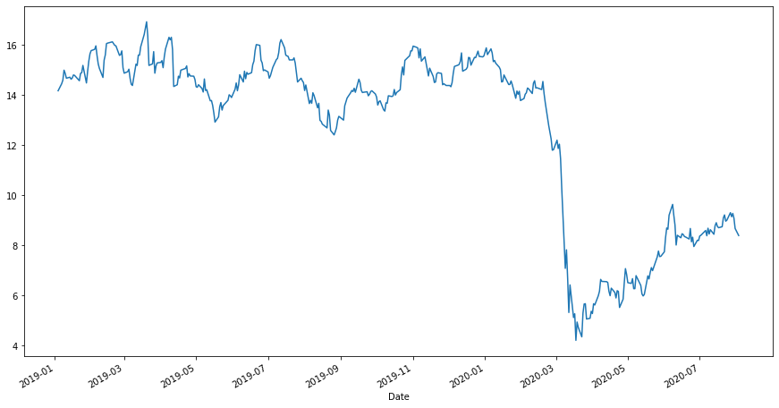

```python
petro['Adj Close'].plot(figsize=(15,8))
title ='VAriação do preços das ações'
plt.show()
```

No gráfico acima, podemos observar, há uma queda drástica no preço das ações por volta de março/ abril de 2020.

As ações da Petrobras chegaram a desabar quase 30% nesta segunda-feira (9), após uma disputa entre Rússia e Arábia Saudita derrubar os preços do petróleo. É a maior queda já registrada.... - Veja mais em

https://economia.uol.com.br/cotacoes/noticias/redacao/2020/03/09/acoes-da-petrobras-tombo-do-petroleo-no-exterior.htm?cmpid=copiaecola

### Variação percentual diária (retornos diários)

> A variação percentual diária no preço das ações é calculada com base na variação percentual entre os preços de fechamento de 2 dias consecutivos. Digamos que o preço de fechamento das ações ontem fosse de R$ 500,00 e hoje as ações fecharam como R$550,00.

Portanto, a variação percentual é de 10%. ou seja ((550–500) / 500) * 100. Nenhum mistério aqui!

> Conseqüentemente, apresentaremos uma nova coluna ' Day_Perc_Change ' indicando os retornos diários no preço das ações. Isso pode ser feito usando a função pct_change () embutida no python.

```python
#Vamos criar uam nova coluna com o nome day-perc-change
petro['Day_Perc_Change'] = petro['Adj Close'].pct_change()*100
petro.head()
```

| Date | Date | Open | High | Low | Close | Adj Close | Volume | Day_Perc_Change |
| --- | --- | --- | --- | --- | --- | --- | --- | --- |
| 2019-01-04 | 2019-01-04 | 14.43 | 14.80 | 14.31 | 14.76 | 14.16 | 21083900 | NaN |
| 2019-01-07 | 2019-01-07 | 14.91 | 15.54 | 14.45 | 15.06 | 14.44 | 37305100 | 1.977401 |
| 2019-01-08 | 2019-01-08 | 15.34 | 15.43 | 15.07 | 15.20 | 14.58 | 17556900 | 0.969529 |
| 2019-01-09 | 2019-01-09 | 15.57 | 15.71 | 15.51 | 15.62 | 14.98 | 19822300 | 2.743484 |
| 2019-01-10 | 2019-01-10 | 15.42 | 15.57 | 15.25 | 15.48 | 14.85 | 15290900 | -0.867824 |

temos valores nulo na coluna Day_Perc_Change , vamos tratar esses valores nulos.

```python
petro.dropna(axis=0, inplace=True)
```

#### Valores diarios em formato de grafico

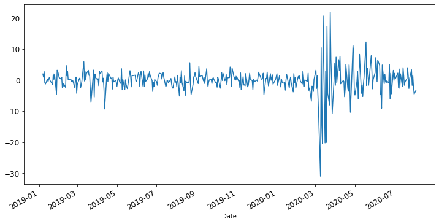

```python
petro['Day_Perc_Change'].plot(figsize=(12,6), fontsize = 12 )
plt.show()
```

Observamos que na maioria dos dias. os retornos estão entre -10 e 10%. Mas no mes de março e abril tivemos um pico negativo de -30%.

#### Histograma de Distribuição de Retorno Diário

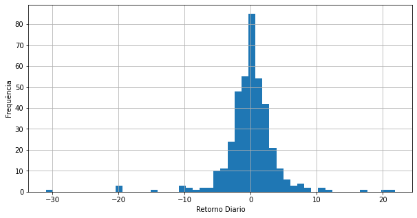

```
count    397.000000
mean      -0.039319
std        4.207368
min      -30.994152
25%       -1.629328
50%        0.124688
75%        1.624294
max       21.839080
Name: Day_Perc_Change, dtype: float64
```

```python
petro['Day_Perc_Change'].hist(bins=50, figsize=(10,5))
plt.xlabel('Retorno Diario')
plt.ylabel('Frequência')
plt.show()

petro.Day_Perc_Change.describe()
```

### Análise de tendência

Em seguida, adicionamos uma nova coluna ' Tendência ' cujos valores são baseados na alteração percentual diária calculada acima. A tendência é determinada abaixo do relacionamento -

```python
#Criar uma função
def tendencia(x):
  if x > -0.5 and x <= 0.5:
    return 'Levemente sem alteração'
  elif x > 0.5 and x <= 1:
    return 'Levemente positivo'
  elif x > -1 and x <= -0.5:
    return 'Levemente Negativo'
  elif x > 1 and x <= 3:
    return 'Positivo'
  elif x > -3 and x <= -1:
    return 'Negativo'
  elif x > 3 and x <= 7:
    return 'Pricipal gannhador'
  elif x > -7 and x <= -3:
    return 'pricnipal Perdedor'
  elif x > 7:
    return 'Corrida do Touro'
  elif x <= -7:
    return 'Corrida do Urso'


petro['Tendencia']= np.zeros(petro['Day_Perc_Change'].count())
petro['Tendencia']= petro['Day_Perc_Change'].apply(lambda x:tendencia(x))
petro.head()
```

| Date | Date | Open | High | Low | Close | Adj Close | Volume | Day_Perc_Change | Tendencia |
| --- | --- | --- | --- | --- | --- | --- | --- | --- | --- |
| 2019-01-07 | 2019-01-07 | 14.91 | 15.54 | 14.45 | 15.06 | 14.44 | 37305100 | 1.977401 | Positivo |
| 2019-01-08 | 2019-01-08 | 15.34 | 15.43 | 15.07 | 15.20 | 14.58 | 17556900 | 0.969529 | Levemente positivo |
| 2019-01-09 | 2019-01-09 | 15.57 | 15.71 | 15.51 | 15.62 | 14.98 | 19822300 | 2.743484 | Positivo |
| 2019-01-10 | 2019-01-10 | 15.42 | 15.57 | 15.25 | 15.48 | 14.85 | 15290900 | -0.867824 | Levemente Negativo |
| 2019-01-11 | 2019-01-11 | 15.22 | 15.36 | 15.12 | 15.29 | 14.66 | 10191300 | -1.279461 | Negativo |

Desejamos ver como as ações estavam em alta nos últimos anos.

Isso pode ser visualizado como um gráfico de setores circulares, com cada setor representando a porcentagem de dias em que cada tendência ocorreu.

Traçaremos um gráfico de pizza para a coluna 'Tendência' para visualizar a frequência relativa de cada categoria de tendência.

Para isso, usaremos a função groupby () com a coluna de tendência para agregar todos os dias com a mesma tendência em um único grupo antes de plotar o gráfico de pizza.

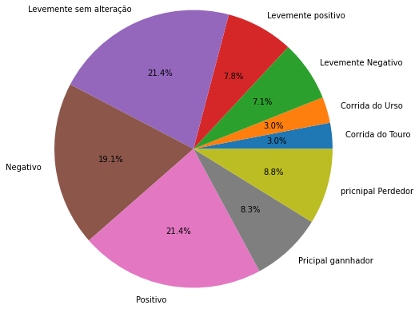

```python
data = petro.groupby('Tendencia')
pie_label = sorted([i for i in petro.loc[:, 'Tendencia'].unique()])
plt.pie(data['Tendencia'].count(), labels = pie_label,
        autopct = '%1.1f%%', radius=2)
plt.show()
```

### Retorno diário e volume

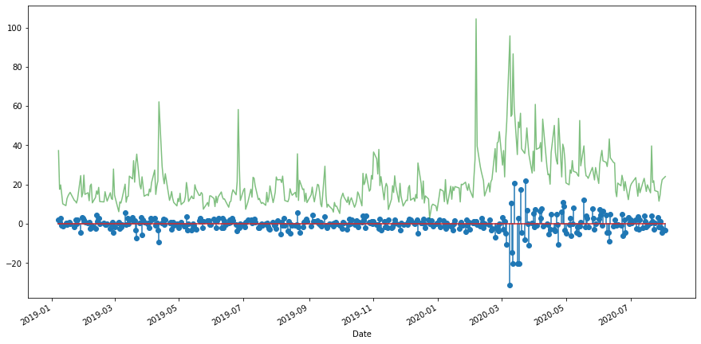

```python
plt.stem(petro['Date'], petro['Day_Perc_Change'])
(petro['Volume']/1000000).plot(figsize=(15, 7.5,),
                               color ='green',
                               alpha = 0.5)
plt.show()
```

(* O volume diário de negociação foi reduzido em escala para corresponder à escala de retorno diário)

Assim, em um determinado dia, se ocorrer um volume de negociação não convencional alto, é possível esperar uma grande mudança no mercado em qualquer direção. O volume de ações negociadas quando associado ao aumento ou queda do preço das ações, em geral, é um indicador da confiança dos traders e investidores em uma determinada empresa.

### Análise de correlação de estoques com plotagem par e plotagem conjunta

NÃO queremos que os estoques sejam relacionados entre si. Matematicamente, o coeficiente de correlação de Pearson (também chamado de valor R de Pearson) entre qualquer par de ações deve ser próximo de 0.

A idéia por trás é simples - suponha que seu portfólio seja composto por ações altamente correlacionadas; se uma ação cair, as demais poderão cair também e você corre o risco de perder todo o seu investimento!

Na seção anterior, usamos o arquivo csv pré-baixado para análise. Nesta seção, teremos a ajuda do pacote do leitor de dados da web do Pandas para extrair os preços dos estoques.

```python
#pip install pandas_datareader
```

```python
# import package
import pandas_datareader.data as web
# set start and end dates
start = datetime.datetime(2019, 3, 15)
end = datetime.datetime(2020, 7, 14)
# extract the closing price data
dados = web.DataReader([ 'BBDC4.SA', 'BBAS3.SA','BPGIX'],
'yahoo', start = start, end = end)['Adj Close']
```

Indice

BBDC4.SA ==== Bradesco

BBAS3.SA ==== BANCO DO BRASIL

BPGIX ======= CAIXA

```python
dados.head(1000)
```

| Symbols Date | BBDC4.SA | BBAS3.SA | BPGIX |
| --- | --- | --- | --- |
| 2019-03-15 | 35.351208 | 51.483345 | 15.937509 |
| 2019-03-18 | 35.536858 | 51.093971 | 16.026215 |
| 2019-03-19 | 34.771053 | 50.001816 | 15.996645 |
| 2019-03-20 | 33.827377 | 48.881168 | 15.898083 |
| 2019-03-21 | 33.084770 | 47.855476 | 15.976933 |
| ... | ... | ... | ... |
| 2020-07-08 | 22.430813 | 34.090000 | 14.170000 |
| 2020-07-09 | 21.931240 | 33.959999 | 13.950000 |
| 2020-07-10 | 22.250967 | 34.139999 | 14.170000 |
| 2020-07-13 | 21.941231 | 33.799999 | 14.170000 |
| 2020-07-14 | 22.310915 | 34.349998 | 14.420000 |

344 rows × 3 columns

Agora vamos procurar e tratar valores nulos

```python
dados.isnull().sum()
```

```
Symbols
BBDC4.SA    13
BBAS3.SA    13
BPGIX        8
dtype: int64
```

```python
#Tratar valore nulos

dados.dropna(inplace=True, axis=0)

dados.head()
```

| Symbols Date | BBDC4.SA | BBAS3.SA | BPGIX |
| --- | --- | --- | --- |
| 2019-03-15 | 35.351208 | 51.483345 | 15.937509 |
| 2019-03-18 | 35.536858 | 51.093971 | 16.026215 |
| 2019-03-19 | 34.771053 | 50.001816 | 15.996645 |
| 2019-03-20 | 33.827377 | 48.881168 | 15.898083 |
| 2019-03-21 | 33.084770 | 47.855476 | 15.976933 |

### Vamos visualisar com o grafico Seaborn de dorma pareada

```python
# armazena retornos diários de todos os estoques acima em um novo
analisar = dados.pct_change()*100
analisar.dropna(inplace = True, how='any', axis=0)
analisar.describe()
```

| Symbols | BBDC4.SA | BBAS3.SA | BPGIX |
| --- | --- | --- | --- |
| count | 322.000000 | 322.000000 | 322.000000 |
| mean | -0.085510 | -0.064260 | -0.011335 |
| std | 3.388965 | 3.494267 | 1.967131 |
| min | -14.274416 | -16.689509 | -11.826347 |
| 25% | -1.491222 | -1.578592 | -0.519118 |
| 50% | -0.126496 | -0.098257 | 0.066699 |
| 75% | 1.428616 | 1.445266 | 0.610420 |
| max | 16.866913 | 17.126078 | 9.674332 |

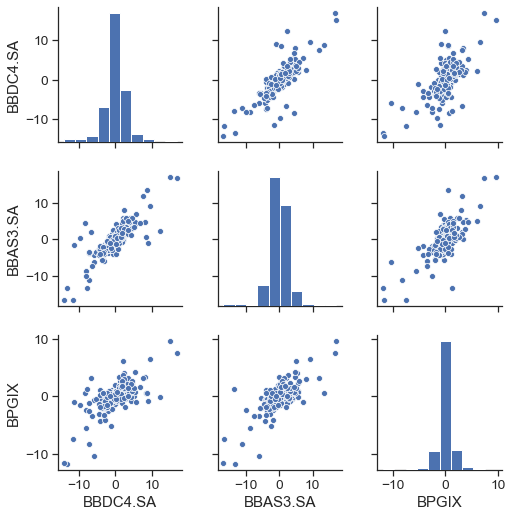

```python
sns.set(style = 'ticks', font_scale= 1.25)
sns.pairplot(analisar)

plt.show()
```

Observe que a análise de correlação é realizada na alteração percentual diária (retornos diários) do preço das ações e não no preço das ações.

Se você observar com cuidado, as plotagens na área triangular inferior são as mesmas que as plotagens na área triangular superior, com apenas os eixos trocados.

Portanto, analisar qualquer conjunto de parcelas seria suficiente.

**Recua:**

Embora os gráficos de pares forneçam uma visualização muito boa de todas as combinações possíveis entre o monte de ações, não fornecem informações detalhadas, como o valor R de Pearson ou o valor p de hipótese nula para quantificar a correlação. É aí que a trama conjunta entra em cena!

Comparação entre o BANCO DO BRASIL X BRADESCO

[output not shown]

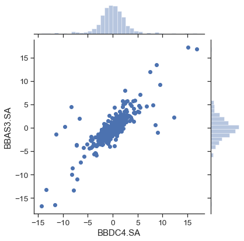

```python
sns.jointplot('BBDC4.SA', 'BBAS3.SA', analisar, kind = 'scatter').annotate(stats.pearsonr)
```

### Análise de volatilidade

A volatilidade é uma medida estática que mede o risco de um ativo, de acordo com a intensidade e frequência de sua oscilação de preço em um determinado período de tempo.

Por meio dela, é possível entender o histórico de um ativo, qual a probabilidade de ele subir ou cair, de acordo com o período de tempo preestabelecido, e qual será a estimativa de oscilação do seu preço no futuro.

Se o preço de um ativo for muito volátil, por exemplo, é sinal de que sua cotação, em relação às flutuações do mercado, oscila muito, tornando sua compra arriscada, mas, por outro lado, proporciona maior possibilidade de lucro no curtíssimo prazo.

Tipos de volatilidade Depois de entender o que é volatilidade é necessário saber em quantos tipos elas se dividem e qual o papel de cada uma delas. Existem três tipos de volatilidade, que podem ser calculadas de maneira diferentes:

Volatilidade histórica A volatilidade histórica é o desvio padrão anualizado, que é calculado de acordo com as variações de preço de um determinado ativo em um período de tempo preestabelecido. Ela serve como balizador de qual será a previsão da volatilidade desse ativo no futuro.

Volatilidade implícita A volatilidade implícita é aquela que calcula a estimativa da volatilidade de um preço no futuro e pode ser obtida com base na volatilidade histórica e nos preços de ativos negociados na Bolsa, como os derivativos.

[CLEAR](https://blog.clear.com.br/o-que-e-volatilidade/?campaignid=1676751011&adgroupid=77260160043&adid=389650790072&gclid=EAIaIQobChMI9MnHnJWC6wIVVgSRCh2qUwjjEAAYAyAAEgICGvD_BwE)

A volatilidade é um dos pilares mais importantes nos mercados financeiros. Diz-se que uma ação tem alta volatilidade se seu valor puder mudar drasticamente em um curto espaço de tempo.

Por outro lado, menor volatilidade significa que o valor das ações tende a ser relativamente estável ao longo de um período de tempo.

Esses movimentos são devidos a vários fatores, incluindo demanda e oferta, sentimentos, ações corporativas, ganância e medo, etc. Matematicamente, a volatilidade é medida usando uma medida estatística chamada 'desvio padrão', que mede a saída de um ativo em relação ao seu valor médio.

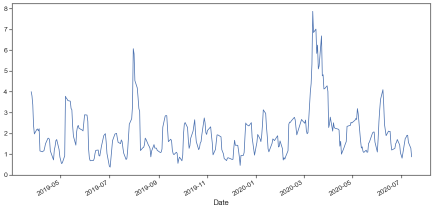

```python
BBDC4 = dados['BBDC4.SA'].rolling(7).std() * np.sqrt(7)
BBDC4.plot(figsize = (15,7))

plt.show()
```

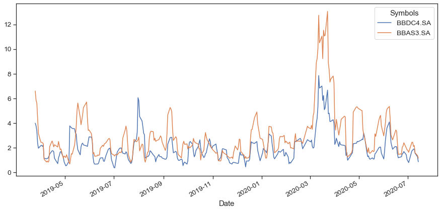

```python
volatil = dados[['BBDC4.SA','BBAS3.SA']].rolling(7).std() * np.sqrt(7)
volatil.plot(figsize=(15,7))

plt.show()
```

Você pode observar que as ações da BBAS3 apresentam maior volatilidade em comparação com as ações da BBDC4.

Muitos traders e investidores buscam investimentos de maior volatilidade para obter lucros mais altos. Se uma ação não se move, não apenas apresenta baixa volatilidade, mas também possui baixo potencial de ganho. Por outro lado, uma ação ou outro título com um nível de volatilidade muito alto pode ter um tremendo potencial de lucro, mas o risco é igualmente alto.

Clauder Noronha